# Endometrial Cancer Grade: Risk Factors.

Cesare

# Introduction

Endometrial cancer (EC) is a type of cancer that begins in the uterus. The uterus is the hollow, pear-shaped pelvic organ where fetal development occurs. The disease begins in the inner layer of the uterus from the glandular epithelial sheet that covers the luminal surface and secretes substances essential for normal menstruation and embryonic development. It is also called uterine cancer.

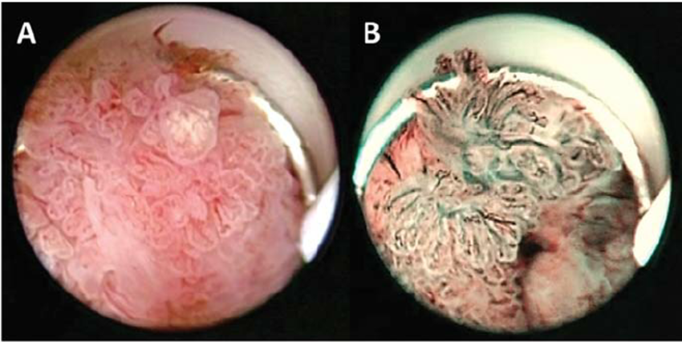

Comparison of visualization of endometrial cancer by (A) white light and (B) Narrow band imaging – NBI hysteroscopy. Papillary protruding lesions can be observed, and expanded, inflectional and coiling atypical vessels are more clearly imaged in dark green on the endometrial surface by NBI.

A description on how abnormal the cancer cells and tissue look under a microscope and how quickly the cancer cells are likely to grow and spread is given by the histologic grade (also called grade and tumor grade). Low-grade cancer cells look more like normal cells and tend to grow and spread more slowly than high-grade cancer cells. Most women diagnosed EC have well-differentiated cancers with low endometrioid histology associated with early-stage disease and favorable outcomes, however there are clinically aggressive histologic subtypes of the disease, such as the serous histotype. Figure shows an image from Kisu et al. (2012)[^1] to have an idea on how bad this desease is.

It is of particular interest for this project to predict whether the the histology grade of an patient is low or high — since it is used to help plan treatment and determine prognosis — and how this grade is related to three risk factors: neovasculation (1 = present, 0 = absent), pulsatility index of arteria uterina (ranging from 0 to 49), and endometrium height (ranging from 0.27 to 3.61) from a Bayesian multilevel perspective. To this purpose, the following logistic mixed effect model

$$\begin{align}
\nonumber E(logit[P(y_{i}=1)]) =& ~~\alpha_{j[i]} + \sum_{k=1}^{3} \beta_k x_{ki} + \epsilon_{i}, for ~ i = 1,...,n,
\end{align}$$

is fitted. Where $\alpha_{j} = \alpha + r_{j} \sim N(\alpha, \sigma^{2}_{\alpha_j})$ is interpreted as an “adjusted” mean for group $j$. Here, $r_j$ is an group - level effect. $\beta_k, k \in \{1,2,3\}$ are the coefficients of the their respective covariates. All them will be estimated from the data. $\epsilon_{ij}$ is an error term.

# Description of the data and the analysis problem

Figure depicts the range of values of the variables on which the model is trained through density plots. This to avoid extrapolations.

[figure not shown]

The analysis provided in this project is distinct from others, since it comes up with the application of a modern sampling method based on Monte Carlo Markov chains (MCMC), and the use of multilevel modeling to tackle the classification problem and infer how the expected value of the response variable relates to the proposed features (risk factors).

# Model and inference configuration

The aforementioned model was fitted to the available research data. Since histology grade ($y$) is a binary outcome a logistic regression model is used. This generalized model uses a sigmoid function — the logit function — as link function allowing it to map continuous values [$-\infty$, $\infty$] into the range of values [$0$, $1$], which is necessary, since probability values need to be between 0 and 1. The log odds (logit) function is defined as

$$\begin{align}
\nonumber logit(x) =& ~~log\left(\frac{x}{1-x}\right)
\end{align}$$

which transformed data from a probability scale. The inverse logit function

$$\begin{align}
\nonumber logit^{-1}(x) =& ~~\frac{1}{1+exp(-x)}
\end{align}$$

take us back to a probability scale. Thus, the probability the $y_{i}$ is given by

$$\begin{align}
\nonumber E(P(y_{i}=1)) =& ~~logit^{-1}(\alpha_{j[i]} + \sum_{k=1}^{3} \beta_k x_{ki} + \epsilon_{i}), for ~ i = 1,...,n.
\end{align}$$

Removing $EH$ from the specification (model 2) was tried for the sake of variegation. This predictor was proven to provide the most predictive power, however. The complete Bayesian multilevel model to be estimate on this project is as follows

$$\begin{align}
\nonumber y_i &\sim Bernoulli(~~logit^{-1}(\alpha_{j[i]} + \sum_{k=1}^{3} \beta_k x_{ki} + \epsilon_{i})) \\
\nonumber \alpha &\sim Student-T(3, 0, 2.5) \\
\nonumber sd_1 &\sim Student-T(3, 0, 2.5) \\
\nonumber z_1 &\sim Normal(0,1)
\end{align}$$

This model involves the use of non-centered parameterization for group-level coefficients, i.e., it defines the independent standard normal coefficient z_1 as parameters and then scale them according to the standard deviations sd_1. For a single group-level term, this happens via r_nv_a = sd_1[1] * z_1[1] in the .stan code. r_nv_a refers to the the vector of group-level coefficients within the grouping factor $NV$. Additionally, the predictor were centered and QR decomposition was used under the hood for the sake of maximizing the sampling efficiency. Since there is no information at hand regarding previous finding on similar model, the use of weakly-informative priors was required. The details on how the inference of the model were ran are as follows. Samples were drawn using NUTS algorithm with 1100 warm up iterations, 500 sampling iterations, 4 chains, and adaptive delta set to 0.9.

# Model diagnostics

Regarding the posterior predictive distribution, the simulated distributions obtained from the fitted model replicates fair well the empirical density of the response. See figure .

[figure not shown]

Empirical distribution Vs. Simulated distributions — A comparison.

[figure not shown]

PSIS graphical diagnostic.

# Results Discussion

This results are robust to changes in the priors. $\alpha$, $PI$, and $EH$ are fixed effects showing that the expected log odds of high histology grade is 6.60; an increment of 1 unit on the pulsatility index of arteria uterina is associated with reduction of 0.04 on the expected log odds of having a high histology grade; and increase in the endometrium height is associated with a decrement of 3.28 on the expected log odds of high grade histology, respectively. $r_{NV1}$ and $r_{NV2}$ are random effects, i.e., they measure the effect of belonging to certain clusters within the data. They indicate that when a patient belongs to the cluster where neovasculation is present, the expected log odds are reduced by 1.58. A increase of 2.38 is expected, otherwise. A visual representation of the posterior distribution of the coefficients is provided in figure . The dashed line represent the region of practical equivalence (ROPE) to test whether the effects are different from zero.

[figure not shown]

Coefficients posterior distributions

[figure not shown]

Log odds ration: NV_2 vs. no NV_1

Regarding our classification task, the accuracy of the model is estimated to be 86%, which is nice given the the data at hand. This value could be improved with a richer dataset with additional observations, features, and the application of some feature engineering techniques, however.

# Conclusion on what was learned from the data analysis & Self-reflection

Carrying out this project was really educative. It not only showed me some interesting finding regarding its main research topic, but also exhibited the beauty and usefulness of Bayesian analysis through the tools and techniques it requires, and the complete distributions over the parameters that it provides as output. Although it demands a bit more, since it requires to write down a complete model in stan language. This doesn’t make it less attractive — at least from my perspective.

Finally, I would like to thank you for reading this report, and congratulate for reaching to its end. In case you would like to keep contact with me, please feel free to write me to cesare@cesare@.com or you can also find me on twitter as @cesare.

# Appendix

## Stan code

```
## functions {
##  vector meansX (matrix X, int D) {
##     vector[D] means_X;
##     for (i in 1:D) {
##         means_X[i] = mean(X[, i]);
##     }
##     return means_X;
##  }
##  matrix centerX (matrix X, int D, int N, vector means_X) {
##     matrix[N, D] Xc;
##     for (i in 1:D) {
##         Xc[, i] = X[, i] - means_X[i];
##     }
##     return Xc;
##  }
## }
##
## data {
##  int<lower = 1> N1, D1,
##     n_nv;
##  array[N1] int<lower = 0, upper = 1> y;
##  array[N1] int<lower = 1, upper = n_nv> nv;
##  matrix[N1, D1] x1;
## }
##
## transformed data {
##  int n_ef = 1;
##
##  vector[D1] meanS = meansX(x1, D1);
##  matrix[N1, D1] X = centerX(x1, D1, N1, meanS);
##
##  // compute and scale QR decomposition
##  matrix[N1, D1] XQ = qr_thin_Q(X) * sqrt(N1 - 1);
##  matrix[D1, D1] XR = qr_thin_R(X) / sqrt(N1 - 1);
## }
##
## parameters {
##  real alpha;
##  vector[D1] beta_Q;
##
```

[output cut: 20 more lines]

```
##  target += std_normal_lpdf(z_1[1]);
##
##  //likelihood
##  target += bernoulli_logit_lpmf(y | mu);
## }
##
## generated quantities {
##  array[N1] real yrep, log_lik;
##  for (i in 1:N1) {
##   log_lik[i] = bernoulli_logit_lpmf(y[i] | mu[i]);
##  }
##  yrep = bernoulli_logit_rng(mu);
##  vector[D1] beta = inverse(XR)*beta_Q;
##  real Intercept = alpha - dot_product(meanS, beta);
## }
```

[^1]: Kisu, I., Banno, K., Tsuji, K., Masuda, K., Ueki, A., Kobayashi, Y., … & Aoki, D. (2012). Narrow band imaging in gynecology: a new diagnostic approach with improved visual identification. International journal of oncology, 40(2), 350-356.
[^2]: Heinze, G. & Schemper, M. Statist. Medic. 21: 2409–2419 (2002).